# Describing text

19 April 2018

This document introduces the steps of going from raw texts to a document term matrix that can be analyzed.

## Reading in data

Let’s take a look a set of UK prime minister speeches from the [EUSpeech](https://dataverse.harvard.edu/dataverse/euspeech) dataset.

NB: Use setwd() to set the working directory to the folder that contains English speeches in the file speeches_uk.csv.

```r
Sys.setlocale(locale = "en_US.UTF-8")
```

```
## [1] "en_US.UTF-8/en_US.UTF-8/en_US.UTF-8/C/en_US.UTF-8/C"
```

```r
#load libraries
library(readtext)
library(quanteda)

#read in speeches
speeches <- readtext("speeches_uk.csv", text_field = "text", encoding = "UTF-8")

#remove p tags
speeches$text <- gsub("<.*?>", "", speeches$text)

#construct a corpus
corpus <- corpus(speeches)
```

## Describing text

Let’s first take a look at language readability, as measured by Flesch Kincaid. `Quanteda` contains quite a number of readability indices, which can be called with the `textstat_readability()` function. Since Flesch Kincaid is a weighted average of word length and sentence length it requires the corpus to contain interpunction.

```r
docvars(corpus, "flesch.kincaid") <- textstat_readability(corpus, "Flesch.Kincaid")[,2]
```

Let’s plot readability of PM speeches over time:

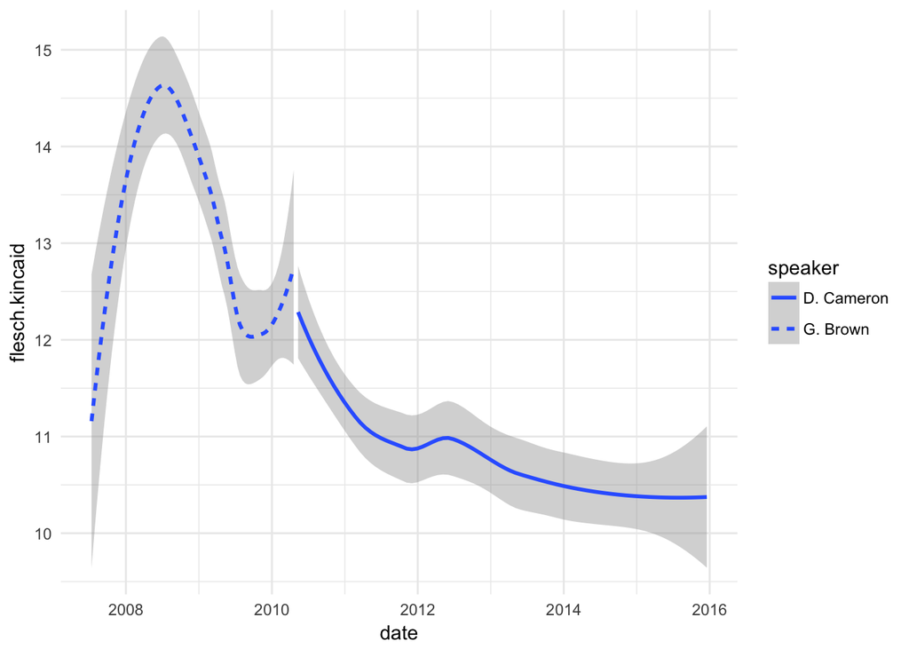

```r
library(ggplot2)

#turn the date variable in a date format instead of character format
docvars(corpus, "date") <- as.Date(docvars(corpus, "date"), "%d-%m-%Y")

#let's look at Cameron and Brown
corpus.cameron.brown <- corpus_subset(corpus, speaker != "T. Blair")

#develop plot
complexity.plot <- ggplot(docvars(corpus.cameron.brown), aes(x = date, y = flesch.kincaid, linetype = speaker))
complexity.plot <- complexity.plot + geom_smooth() + theme_minimal()
print(complexity.plot)
```

We can use the `kwic()` to function to obtain the context in which certain keywords appear. Let’s take a look at how David Cameron talked about Syria:

```r
corpus.cameron <- corpus_subset(corpus, speaker == "D. Cameron")
tokenized.corpus.cameron <- tokens(corpus.cameron)

syria.kw <- kwic(tokenized.corpus.cameron, 'syria*')
nrow(syria.kw)
```

```
## [1] 614
```

```r
head(syria.kw)
```

```
##
##  [text1, 162]   in humanitarian assistance for the |    Syrian    |
##  [text1, 253]     to resettle 22,000 refugees from |    Syria     |
##  [text1, 295] United Kingdom would resettle 20,000 |    Syrian    |
##  [text1, 316]         we have resettled over 1,000 |    Syrian    |
##  [text1, 378]            all those affected by the |    Syrian    |
##  [text1, 607]         the instability in Libya and | Syria.That's |
##
##  conflict and deployed HMS Enterprise
##  over 2 years and to
##  refugees during this Parliament.And we
##  refugees from camps in Turkey
##  crisis with the conference we
##  why it's so important that
```

Let’s turn the corpus into a dfm using the `dfm()` function in `quanteda`:

```r
corpus.dfm <- dfm(corpus, stem = TRUE, remove=stopwords("english"), remove_punct=TRUE)
#let's select those tokens that appear in at least 10 documents
corpus.dfm = dfm_trim(corpus.dfm, min_docfreq = 10)
corpus.dfm
```

```
## Document-feature matrix of: 787 documents, 4,205 features (89.5% sparse).
```

The `textstat_simil()` function lets us calculate the cosine similarity between speeches. For other similarity or distance measures check the `quanteda` reference manual.

```r
similarity <- textstat_simil(corpus.dfm, margin = "documents" , method = "cosine")
similarity <- as.matrix(similarity)
which(similarity == max(similarity), arr.ind = TRUE)
```

```
##         row col
## text654 654 652
## text652 652 654
```